# Homework: hardware aware computing

# Problem 1: Accelerated principal component calculation via Rcpp

In prior homework, we implemented an approach to calculating the principal components of a lag-1 auto-regressive process without explicitly representing its covariance matrix $\boldsymbol{\Sigma}$. To this end, we only needed to provide the Lanczos algorithm a function for carrying out the matrix-vector multiplication $\boldsymbol{v} \to \boldsymbol{\Sigma}^{-1} \boldsymbol{v}$. Here we will try to make the function more efficient by re-writing it in Rcpp.

Complete the implementation of `ar_precision_matvec` in the `structured_matvec.cpp` file below and make the compiled function available to R via `sourceCpp`.

```r
sourceCpp(file.path("../src", "structured_matvec.cpp"))
```

Make sure the `ar_precision_matvec` function in Rcpp is correctly implemented by comparing its output to an R implementation. Testing your functions become particularly important when using Rcpp because C++ has far fewer built-in checks than R — e.g. C++ won’t stop you from accessing non-existing/out-of-bounds elements of an array!

```r
ar_length <- 4096
auto_corr <- .9

ar_precision_matvec_R <- function(v, auto_corr) {
  n <- length(v)
  if (n < 3) {
    stop("Error: function assumes the AR process of length at least 3.")
  }
  # Multiplication by the diagonal
  result <- (1 + auto_corr^2) * v
  result[1] <- v[1]
  result[n] <- v[n]
  # Add contributions from the off-diagonals
  result[1:(n - 1)] <- result[1:(n - 1)] - auto_corr * v[2:n]
  result[2:n] <- result[2:n] - auto_corr * v[1:(n - 1)]
  result <- result / (1 - auto_corr^2)
  return(result)
}
```

```r
# Check the output of your Rcpp function `ar_precision_matvec`
v = rep(1, ar_length)
yr = ar_precision_matvec_R(v, auto_corr)
yc = ar_precision_matvec(v, auto_corr)

assert("Rcpp function gives the same result as R function", {
  are_all_close(yr, yc)
})
```

Benchmark performance of the R and Rcpp implementations of `ar_precision_matvec`. Then use the Rcpp implementation to find the top 10 principal components of $\boldsymbol{\Sigma}$ via Lanczos algorithm. How much faster is it compared to explicit eigen decomposition of $\boldsymbol{\Sigma}$?

```r
# Comare performences of the R and Rcpp implementation
bench::mark(ar_precision_matvec_R(v, auto_corr))
```

```
# A tibble: 1 x 6
  expression                             min median `itr/sec` mem_alloc `gc/sec`
  <bch:expr>                          <bch:> <bch:>     <dbl> <bch:byt>    <dbl>
1 ar_precision_matvec_R(v, auto_corr)  100us  112us     8185.     289KB     55.4
```

```r
bench::mark(ar_precision_matvec(v, auto_corr))
```

```
# A tibble: 1 x 6
  expression                            min  median `itr/sec` mem_alloc `gc/sec`
  <bch:expr>                        <bch:t> <bch:t>     <dbl> <bch:byt>    <dbl>
1 ar_precision_matvec(v, auto_corr)  12.7us  13.5us    68560.    39.7KB     54.9
```

For the matrix-vector multiplication, Rcpp is faster than R implementation.

```r
# Use your Rcpp implementation and compute the principal components
system.time(
  ar_eig <- eigs_sym(
    ar_precision_matvec,
    n = ar_length, args = auto_corr,
    k = 10, which = "SM",
    opts = list(
      ncv = 100, # Spectrum distribution of AR-1 process is not very spread out on the extreme ends and is actually a hard case for Lanczos. So it helps to have more Lanczos vectors than the default for faster convergence.
      maxitr = 10^3, # Cap it just in case
      retvec = TRUE # More efficient to do without eigenvectors when not needed
    ),
  )
)
# eigen decomp
eigen_decomp_AR1_cov = function(ar_length,auto_corr, k){
  Sigma = lapply(1:ar_length, function(i){
    auto_corr^abs(i-c(1:ar_length))
  })
  Sigma = do.call(rbind,Sigma)
  eigen_decomp = eigen(Sigma)
  eigen_vec = eigen_decomp$vectors[,1:k]
  eigen_val <- eigen_decomp$values[1:k]
  return(list(values = eigen_val, vectors = eigen_vec))
}
system.time(
  ar_eig_decomp <- eigen_decomp_AR1_cov(ar_length = ar_length, auto_corr = auto_corr, k = 10)
)
```

[output not shown]

**Bonus Problem:** A symmetric ‘$k$-banded’ matrices of size $n \times n$ can be efficiently stored in a $n \times (k + 1)$ matrix with no loss of information; see [Wikipedia page on banded matrices](https://en.wikipedia.org/wiki/Band_matrix#Band_storage). Complete the implementation of `sym_banded_matvec` in the `structured_matvec.cpp` file. How does the `sym_banded_matvec` performance compare with `ar_precision_matvec`? What aspects of hardware designs might be contributing to the relative performance?

The `sym_banded_matvec` has similar (slightly better) performance compared with `ar_precision_matvec`. The vector size could affect the relative performance.

```r
banded_mat = cbind(c(1, rep(1 + auto_corr^2, ar_length - 2), 1), c(rep(- auto_corr, ar_length - 1), 0))
banded_mat = banded_mat / (1 - auto_corr^2)
yb = sym_banded_matvec(v, banded_mat)

assert("Rcpp function using symmetric banded matrices gives the same result as R function", {
  are_all_close(yr, yb)
})

bench::mark(sym_banded_matvec(v, banded_mat))
```

```
# A tibble: 1 x 6
  expression                            min  median `itr/sec` mem_alloc `gc/sec`
  <bch:expr>                       <bch:tm> <bch:t>     <dbl> <bch:byt>    <dbl>
1 sym_banded_matvec(v, banded_mat)   12.3us  13.7us    66649.    38.7KB     53.4
```

```r
bench::mark(ar_precision_matvec(v, auto_corr))
```

```
# A tibble: 1 x 6
  expression                            min  median `itr/sec` mem_alloc `gc/sec`
  <bch:expr>                        <bch:t> <bch:t>     <dbl> <bch:byt>    <dbl>
1 ar_precision_matvec(v, auto_corr)  12.7us  14.1us    65930.    34.5KB     59.4
```

# Problem 2: Multiplying two matrices ain’t quite what you learned in your linear algebra class

## Part I: Paying homage to your linear algebra teacher

As we all learned in our linear algebra class, the matrix product $\boldsymbol{C} = \boldsymbol{A} \boldsymbol{B}$ of $\boldsymbol{A} \in \mathbb{R}^{n \times r}$ and $\boldsymbol{B} \in \mathbb{R}^{r \times m}$ has its elements defined as
$$C_{ij} = \sum_{k = 1}^r A_{ik} B_{kj}.$$
So a conceptually natural way to implement a matrix multiplication is looping through each row of $\boldsymbol{A}$ and column of $\boldsymbol{B}$, taking inner products of the pairs of vectors:

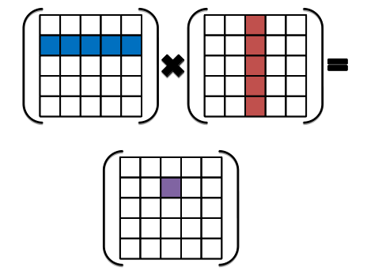

Implement a matrix-matrix multiplication based on this approach as `row_col_dot_matmat` using the starter code provided in the `matmat.cpp` file. Then check that its output agrees with the base R matrix multiplication.

```r
sourceCpp(file.path("../src", "matmat.cpp"))
```

```r
n_row <- 512L
n_inner <- 1024L
n_col <- 256L
set.seed(1)
A <- matrix(rnorm(n_row * n_inner), nrow = n_row, ncol = n_inner)
B <- matrix(rnorm(n_inner * n_col), nrow = n_inner, ncol = n_col)
```

```r
# Check the output of `row_col_dot_matmat`
AB.R = A %*% B
AB.C = row_col_dot_matmat(A, B)
assert("Rcpp function gives the same result as R function", {
  are_all_close(AB.R, AB.C)
})
```

## Part II: Going one step beyond your linear algebra class

We now consider an alternative approach to matrix-matrix multiplications, noting that we can think of a matrix product $\boldsymbol{A} \cdot \boldsymbol{B}$ as each column of $\boldsymbol{B}$ multiplied by $\boldsymbol{A}$:
$$\boldsymbol{A} \cdot \boldsymbol{B} = \big[ \, \boldsymbol{A} \boldsymbol{b}_1 \, | \, \ldots \, | \, \boldsymbol{A} \boldsymbol{b}_m \, \big].$$
Recalling from lecture that “column-oriented” matrix-vector multiplication is more efficient than “row-oriented” one for R matrices, implement `col_oriented_matmat` (in `matmat.cpp`) that loops through each column of $\boldsymbol{B}$ applying the column-oriented matrix-vector multiplication. Then compare performances of `row_col_dot_matmat` and `col_oriented_matmat` (but only after you test your column-oriented implementation, for heaven’s sake!). Which one is faster and why?

The `col_oriented_matmat` is faster. The `row_col_dot_matmat` is a naive algorithm with triple for-loops that takes $O(nmr)$ time, while `col_oriented_matmat` decomposes the matrix-matrix multiplication into $m$ matrix-vector multiplication which could avoid some for-loops.

```r
# Check and benchmark
AB.col = col_oriented_matmat(A, B)
assert("Rcpp function col_oriendted_matmat gives the same result as R function", {
  are_all_close(AB.R, AB.col)
})
bench::mark(row_col_dot_matmat(A, B))
```

```
# A tibble: 1 x 6
  expression                    min   median `itr/sec` mem_alloc `gc/sec`
  <bch:expr>               <bch:tm> <bch:tm>     <dbl> <bch:byt>    <dbl>
1 row_col_dot_matmat(A, B)    387ms    471ms      2.13    1.01MB        0
```

```r
bench::mark(col_oriented_matmat(A, B))
```

```
# A tibble: 1 x 6
  expression                     min   median `itr/sec` mem_alloc `gc/sec`
  <bch:expr>                <bch:tm> <bch:tm>     <dbl> <bch:byt>    <dbl>
1 col_oriented_matmat(A, B)    142ms    152ms      6.55    2.02MB        0
```

Also compare with performance of the matrix-matrix multiplication via `%*%` in R, which uses whatever the BLAS library your R was configured with. (You can find out which BLAS library R is using via `sessionInfo()` or `extSoftVersion()`.)

```r
# Fill in
bench::mark(A %*% B)
```

```
# A tibble: 1 x 6
  expression      min   median `itr/sec` mem_alloc `gc/sec`
  <bch:expr> <bch:tm> <bch:tm>     <dbl> <bch:byt>    <dbl>
1 A %*% B       127ms    128ms      7.49       1MB        0
```

When benchmarking alternative implementations (or alternative algorithms, more generally), keep in mind that the relative performance depends significantly on the size of a test problem. It is important, therefore, to benchmark your implementation/algorithm on problems of realistic size. See the benchmark results of linear algebra libraries from [the Eigen development team](https://eigen.tuxfamily.org/index.php?title=Benchmark) and the results under “Gcbd benchmark” in [this github repository](https://github.com/andre-wojtowicz/blas-benchmarks), for example.

## Part III: Doing it the right way

Part I & II were simply designed to torture you illustrate how much an algorithm’s performance depends on whether or not it respects an underlying representation of data. Neither of the approaches we’ve discussed, however, is the most effective way to multiply two matrices on modern hardware. Dedicated linear algebra libraries typically deploy *blocking*, dividing the matrices $\boldsymbol{A}$ and $\boldsymbol{B}$ into sub-matrices of appropriate size and carrying out multiplications block-wise. This approach is designed to minimize the data motion between CPU and RAM by re-using the same pieces of data as much as possible once they travel all the way from RAM to L1 cache.

In practice, we of course shouldn’t try to implement (let alone optimize) an operation ourselves when there already are efficient existing software libraries. (But, if you are interested in learning more about how the optimized matrix multiplication works, Sec 1.5.4. of Golub and Van Loan (2013) is a good place to start. Also, I found nice lecture slides on this topic [here](https://cs.brown.edu/courses/cs033/lecture/18cacheX.pdf).) The `matmat_via_eigen` function provided in `matmat_eigen.cpp` calls the matrix-matrix multiplication from [Eigen](https://eigen.tuxfamily.org/), a C++ linear algebra library, through RcppEigen.

```r
sourceCpp(file.path('../src', 'matmat_eigen.cpp'))
```

```r
# Check and benchmark
AB.eigen = matmat_via_eigen(A, B)
assert("Rcpp function matmat_via_eigen gives the same result as R function", {
  are_all_close(AB.R, AB.eigen)
})
bench::mark(matmat_via_eigen(A, B))
```

```
# A tibble: 1 x 6
  expression                  min   median `itr/sec` mem_alloc `gc/sec`
  <bch:expr>             <bch:tm> <bch:tm>     <dbl> <bch:byt>    <dbl>
1 matmat_via_eigen(A, B)   28.9ms   38.1ms      26.8    1.01MB     2.06
```

`matmat_via_eigen` apparently outperforms other methods.